# Angle

2018-03-28

This document serves to provide insight into how a trajectory inference method was used and wrapped. Feel free to discuss implementation-specific details by [creating an issue](https://github.com/dynverse/dynmethods/issues) on GitHub, or improve the wrapper and create a pull request.

```r
library(tidyverse)
```

```r
library(dynmethods)
library(dynwrap)
library(dynutils)
library(dynplot)
```

# Description

This is a control method for inferring cyclic trajectories in a very simple approach, consisting of a dimensionality reduction step and followed by calculating the angle between the first and the second component.

The wrapper can be accessed using the `description_angle` function.

```r
method <- description_angle()
```

This description contains information on which packages need to have been installed in order to run the method and what are the parameters.

```r
str(method, max.level = 1)
```

```
## List of 8
##  $ name            : chr "Angle"
##  $ short_name      : chr "angle"
##  $ package_loaded  : NULL
##  $ package_required: NULL
##  $ par_set         :List of 2
##   ..- attr(*, "class")= chr "ParamSet"
##  $ properties      : NULL
##  $ run_fun         :function (expression, dimred = "pca")
##  $ plot_fun        :function (prediction)
##   ..- attr(*, "srcref")=Class 'srcref'  atomic [1:8] 46 15 53 1 15 1 377 384
##   .. .. ..- attr(*, "srcfile")=Classes 'srcfilealias', 'srcfile' <environment: 0x589c098>
##  - attr(*, "class")= chr [1:2] "dynmethod::description" "list"
```

```r
method$par_set
```

```
##            Type len Def               Constr Req Tunable Trafo
## dimred discrete   - pca pca,mds,tsne,ica,lle   -    TRUE     -
```

# Example

First we retrieve a toy dataset from http://github.com/dynverse/dyntoy.

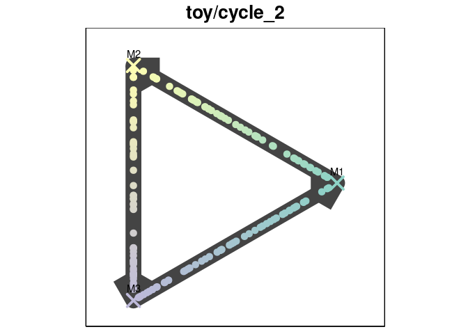

```r
toy_tasks <- dyntoy::toy_tasks %>%
  filter(model == "cycle") %>%
  slice(2)
toy_task <- toy_tasks %>% extract_row_to_list(1)

plot_default(toy_task)
```

We extract the default parameters from the method.

```r
defprm <- get_default_parameters(method)
```

```r
out <- execute_method(toy_tasks, method, parameters = defprm)[[1]]
```

The output will consist of a summary and the model. The summary will contain information pertaining the execution of the method, while the model will contain the trajectory inferred by the method.

```r
out$summary %>% knitr::kable()
```

| method_name | method_short_name | task_id | time_sessionsetup | time_preprocessing | time_method | time_postprocessing | time_wrapping | time_sessioncleanup | error | num_files_created | num_setseed_calls | prior_df |
| --- | --- | --- | --- | --- | --- | --- | --- | --- | --- | --- | --- | --- |
| Angle | angle | toy/cycle_2 | 0.0028157 | 9.32e-05 | 0.0057244 | 0.1609828 | 0.0001738 | 0.0005841 | NULL | 0 | 0 | list(prior_type = logical(0), prior_names = character(0)) |

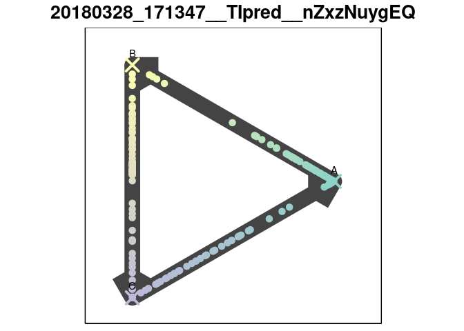

```r
model <- out$model

plot_default(model)
```

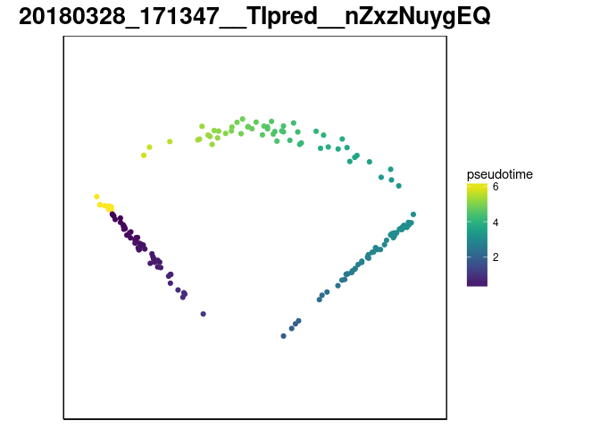

```r
plot_trajectory(model, method)
```

# Wrapper implementation

This section will detail the specific wrapper implementation by applying it on the toy dataset, and should follow the same implementation structure as the https://github.com/dynverse/dynmethods/blob/master/R/ti_angle.R.

In the first step, a dimensionality reduction to two dimensions is computed. By default, this is PCA. Here, it is assumed that the dimensionality reduction will be centered around the origin 0.

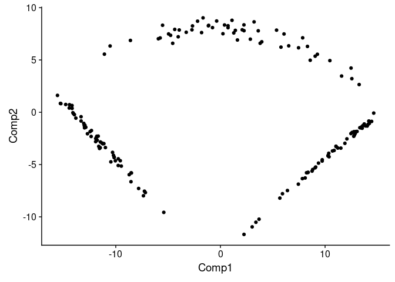

```r
expression <- toy_task$expression
dimred <- dynmethods:::dimred(expression, method = defprm$dimred, ndim = 2)

# Plot dimred
dimred_df <- data.frame(dimred) %>% rownames_to_column("cell_id")
ggplot(dimred_df) +
  geom_point(aes(Comp1, Comp2)) +
  coord_equal() +
  cowplot::theme_cowplot()
```

The ordering of the cells is computed by calculating the degree of each cell with respect to the origin. The bearing is transformed to a [0,1] range.

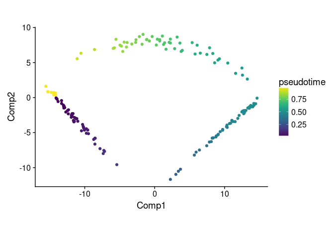

```r
pseudotimes <- atan2(dimred[,2], dimred[,1]) / 2 / pi + .5

dimred_df <- dimred_df %>% mutate(pseudotime = pseudotimes[cell_id])
ggplot(dimred_df) +
  geom_point(aes(Comp1, Comp2, colour = pseudotime)) +
  coord_equal() +
  viridis::scale_color_viridis() +
  cowplot::theme_cowplot()
```

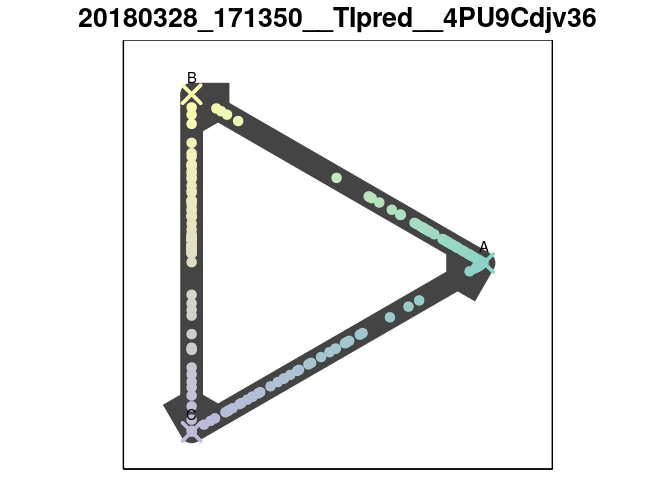

```r
prediction <- wrap_prediction_model(
  cell_ids = rownames(expression)
) %>% add_cyclic_trajectory(
  pseudotimes = pseudotimes,
  do_scale_minmax = FALSE
) %>% add_dimred(
  dimred = dimred
)

plot_default(prediction)
```

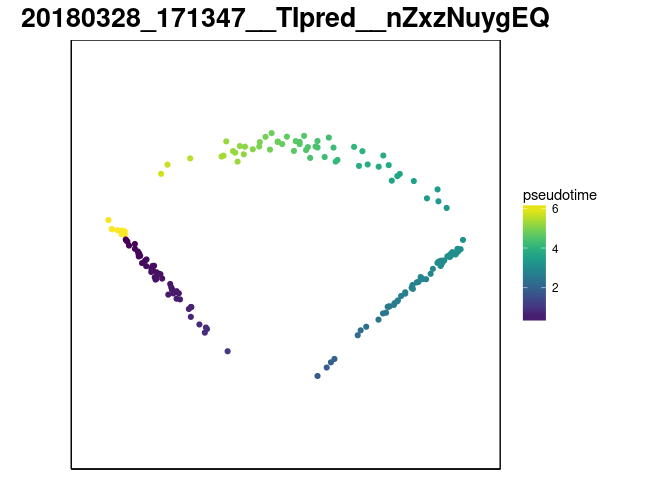

```r
plot_trajectory(model, method)
```

# Quality control

None, since this is a control method.